# Unsupervised_Learning

Alisha Gumber

11/25/2019

```r
HCV_bin <- read_csv("/Users/alishagumber/Desktop/Machine\ Learning/Hep_C_dataset/HCV-Egy-Data.csv")
# filter dataset for variables I will be using (drop columns 17-27).
HCV_bin <- HCV_bin[-c(17:28)]
```

```r
HCV_bin$Fever <- ifelse(HCV_bin$Fever == 2, 0, 1)
HCV_bin$Gender <- ifelse(HCV_bin$Gender == 2, 1, 0)
HCV_bin$`Nausea/Vomting` <- ifelse(HCV_bin$`Nausea/Vomting` == 2, 0, 1)
HCV_bin$Headache <- ifelse(HCV_bin$Headache == 2, 0, 1)
HCV_bin$Diarrhea <- ifelse(HCV_bin$Diarrhea == 2, 0, 1)
HCV_bin$`Fatigue & generalized bone ache` <- ifelse(HCV_bin$`Fatigue & generalized bone ache` == 2, 0, 1)
HCV_bin$Jaundice <- ifelse(HCV_bin$Jaundice == 2, 0, 1)
HCV_bin$`Epigastric pain` <- ifelse(HCV_bin$`Epigastric pain` == 2, 0, 1)

#View(HCV_bin)
```

Since many models work best with binary responses, i’m converting the histological stage into a binary response, with either a diagnosis of severe (stages 3 and 4) or not severe (stage 1 and 2)

```r
# convert histological stage to binary response
Severe = ifelse(HCV_bin$`Baselinehistological staging`>=3, "Severe", "Not_Severe")
HCV = data.frame(HCV_bin, Severe)

head(HCV)
```

```
##   Age Gender BMI Fever Nausea.Vomting Headache Diarrhea
## 1  56      0  35     0              1        1        1
## 2  46      0  29     1              0        0        1
## 3  57      0  33     0              0        0        0
## 4  49      1  33     1              0        1        0
## 5  59      0  32     1              1        0        1
## 6  58      1  22     0              0        0        1
##   Fatigue...generalized.bone.ache Jaundice Epigastric.pain   WBC     RBC HGB
## 1                               0        0               0  7425 4248807  14
## 2                               0        0               1 12101 4429425  10
## 3                               1        1               1  4178 4621191  12
## 4                               1        0               1  6490 4794631  10
## 5                               0        0               0  3661 4606375  11
## 6                               0        0               1 11785 3882456  15
##     Plat AST.1 ALT.1 Baselinehistological.staging     Severe
## 1 112132    99    84                            2 Not_Severe
## 2 129367    91   123                            2 Not_Severe
## 3 151522   113    49                            4     Severe
## 4 146457    43    64                            3     Severe
## 5 187684    99   104                            1 Not_Severe
## 6 131228    66   104                            4     Severe
```

Since all the numeric variables are on different scales, I will scale the data

```r
HCV[1:16] <- lapply(HCV[1:16], function(x) c(scale(x, center = TRUE, scale = TRUE)))
```

```r
# rename some columns for easier analysis
colnames(HCV)[colnames(HCV)=="Fatigue...generalized.bone.ache"] <- "fatigue_and_bodyache"
colnames(HCV)[colnames(HCV)=="Epigastric.pain"] <- "epigastric_pain"
colnames(HCV)[colnames(HCV)=="Baselinehistological.staging" ] <- "histological_stage"
colnames(HCV)[colnames(HCV)=="AST.1" ] <- "AST_1"
colnames(HCV)[colnames(HCV)=="ALT.1" ] <- "ALT_1"
colnames(HCV)[colnames(HCV)=="Nausea.Vomting" ] <- "nausea_vomiting"
```

# ICA

From looking at my variable distributions, this data does not seem to have a normal (Gaussian) distribution, so I will first try ICA as my method of unsupervised learning.

Create a matrix S with the independent components

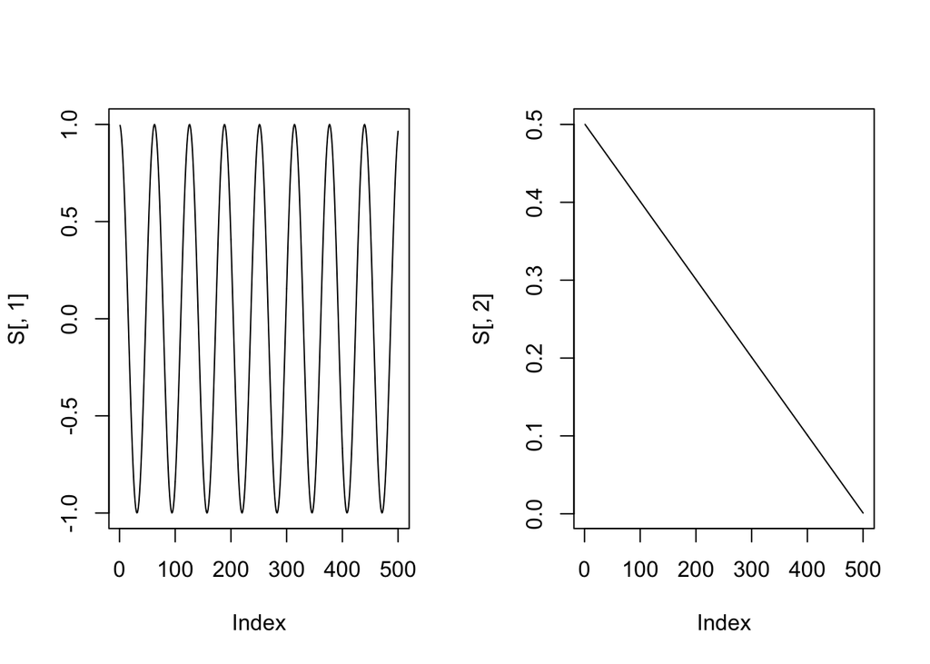

```r
#create two signals
S <- cbind(cos((1:500)/10), ((500:1)/1000))

par(mfcol = c(1, 2))
plot(S[,1], type="l")
plot(S[,2], type="l")
```

Create a mixing matrix A

```r
A <- matrix(c(0.5, 0.7, 0.423, 0.857), 2, 2)
```

Mix S using A

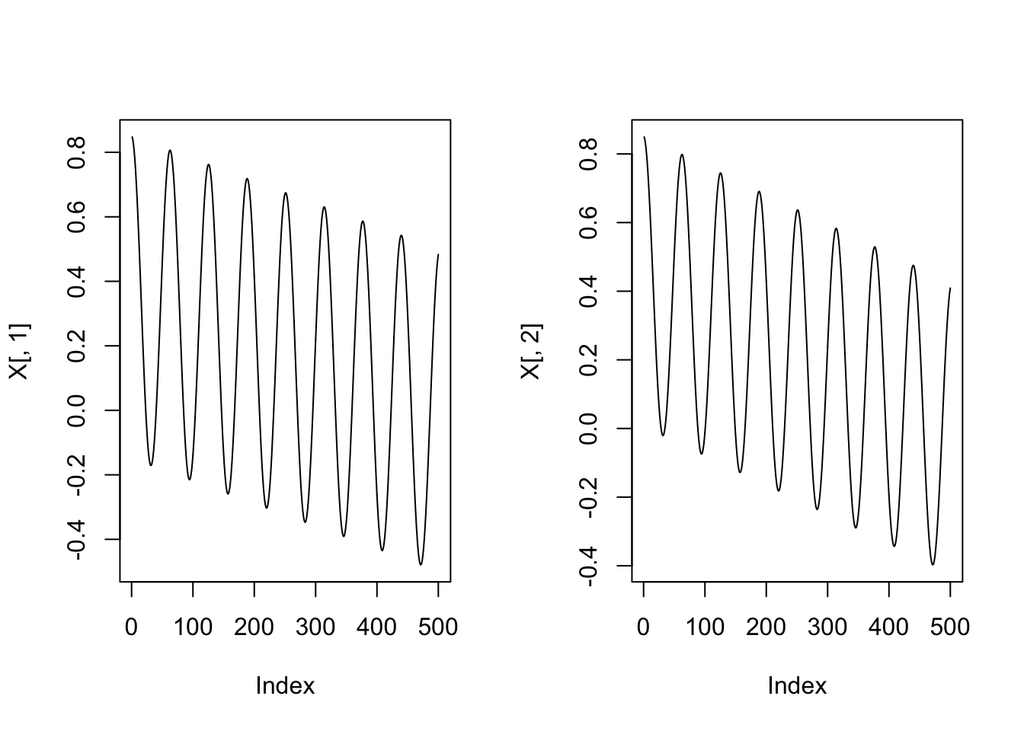

```r
X <- S %*% A
par(mfcol = c(1, 2))
plot(X[,1], type="l")
plot(X[,2], type="l")
```

```r
ica <- fastICA((HCV[1:16]), 4, alg.typ = "parallel", fun = "logcosh", alpha = 1,
             method = "R", row.norm = FALSE, maxit = 200,
             tol = 0.0001, verbose = TRUE)
```

```
## Centering
```

```
## Whitening
```

```
## Symmetric FastICA using logcosh approx. to neg-entropy function
```

```
## Iteration 1 tol = 0.9207267
```

```
## Iteration 2 tol = 0.6148295
```

```
## Iteration 3 tol = 0.1374891
```

```
## Iteration 4 tol = 0.5684443
```

```
## Iteration 5 tol = 0.09379581
```

```
## Iteration 6 tol = 0.9553667
```

```
## Iteration 7 tol = 0.9336673
```

```
## Iteration 8 tol = 0.7346834
```

```
## Iteration 9 tol = 0.08976487
```

```
## Iteration 10 tol = 0.01334344
```

```
## Iteration 11 tol = 0.1320344
```

```
## Iteration 12 tol = 0.695699
```

```
## Iteration 13 tol = 0.1319533
```

```
## Iteration 14 tol = 0.6861007
```

```
## Iteration 15 tol = 0.06387227
```

```
## Iteration 16 tol = 0.5182056
```

```
## Iteration 17 tol = 0.04788344
```

```
## Iteration 18 tol = 0.05012676
```

```
## Iteration 19 tol = 0.03001722
```

```
## Iteration 20 tol = 0.01486907
```

```
## Iteration 21 tol = 0.008523707
```

```
## Iteration 22 tol = 0.003753618
```

```
## Iteration 23 tol = 0.001948993
```

```
## Iteration 24 tol = 0.0008901934
```

```
## Iteration 25 tol = 0.0004455376
```

```
## Iteration 26 tol = 0.000208194
```

```
## Iteration 27 tol = 0.0001025171
```

```
## Iteration 28 tol = 4.850116e-05
```

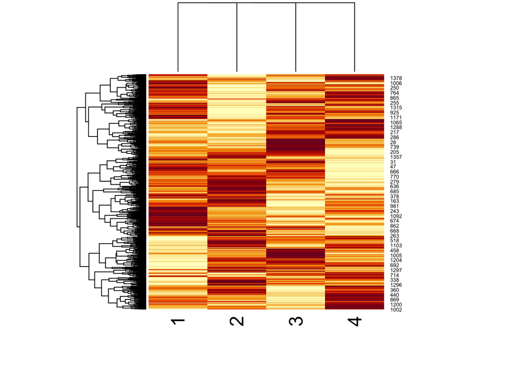

```r
heatmap(ica$S)
```

```r
ica2 <- fastICA((HCV[1:16]), 2, alg.typ = "parallel", fun = "logcosh", alpha = 1,
             method = "R", row.norm = FALSE, maxit = 200,
             tol = 0.0001, verbose = TRUE)
```

```
## Centering
```

```
## Whitening
```

```
## Symmetric FastICA using logcosh approx. to neg-entropy function
```

```
## Iteration 1 tol = 0.01350762
```

```
## Iteration 2 tol = 0.01168805
```

```
## Iteration 3 tol = 0.004728881
```

```
## Iteration 4 tol = 0.00141373
```

```
## Iteration 5 tol = 0.0004034278
```

```
## Iteration 6 tol = 0.0001159993
```

```
## Iteration 7 tol = 3.370711e-05
```

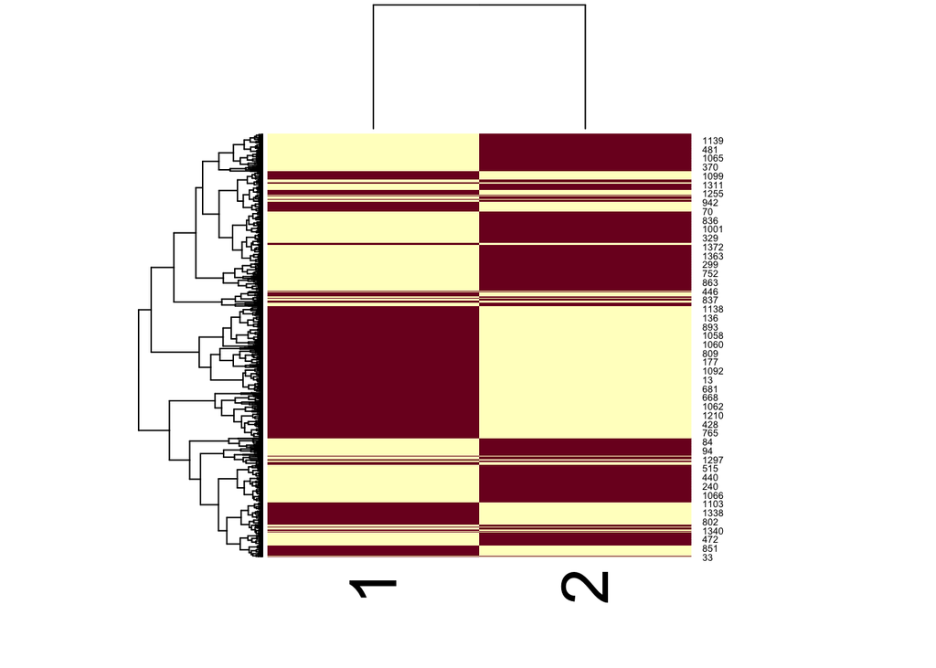

```r
heatmap(ica2$S)
```

# PCA

Since ICA didn’t tell me much about the data, i’ll try PCA as well just to see if it produces any useful information about potential clusters. Since the distribution of the variables were non-Gaussian, I do not expect this to produce very useful information.

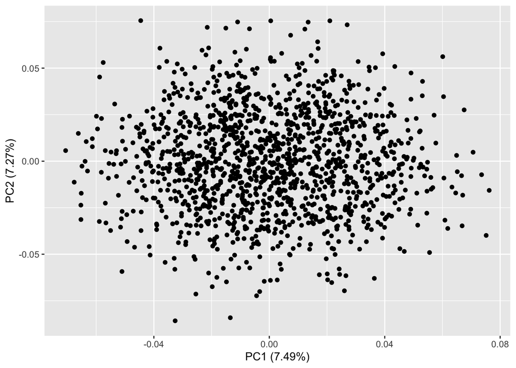

```r
# PCA
autoplot(prcomp(HCV[1:16]))
```

According the PCA plot, PC1 account 7.49% of the variance, and PC2 account for 7.27% of the variance. Just from looking at the plot, there don’t seem to be any identifiable clusters.

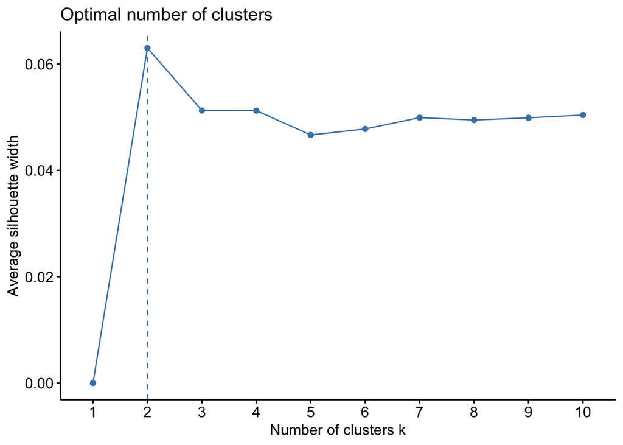

```r
# I will use silhouette anaylsis to determine the optimal number of clusters for the k-means clustering method.
sil <- fviz_nbclust((HCV[1:16]), kmeans, method='silhouette')
sil
```

```r
# The silhouette analysis determine that 2 clusters are optimal, which seems good since I split the dataset into patients who have 'Severe' and 'Not Severe' liver fibrosis.
# K-means clustering:

kmeans_clust <- kmeans(HCV[1:16], 2)
str(kmeans_clust)
```

```
## List of 9
##  $ cluster     : int [1:1385] 2 1 1 1 2 1 2 2 2 2 ...
##  $ centers     : num [1:2, 1:16] 0.0109 -0.01073 0.0253 -0.0249 -0.00827 ...
##   ..- attr(*, "dimnames")=List of 2
##   .. ..$ : chr [1:2] "1" "2"
##   .. ..$ : chr [1:16] "Age" "Gender" "BMI" "Fever" ...
##  $ totss       : num 22144
##  $ withinss    : num [1:2] 10292 10448
##  $ tot.withinss: num 20740
##  $ betweenss   : num 1404
##  $ size        : int [1:2] 687 698
##  $ iter        : int 1
##  $ ifault      : int 0
##  - attr(*, "class")= chr "kmeans"
```

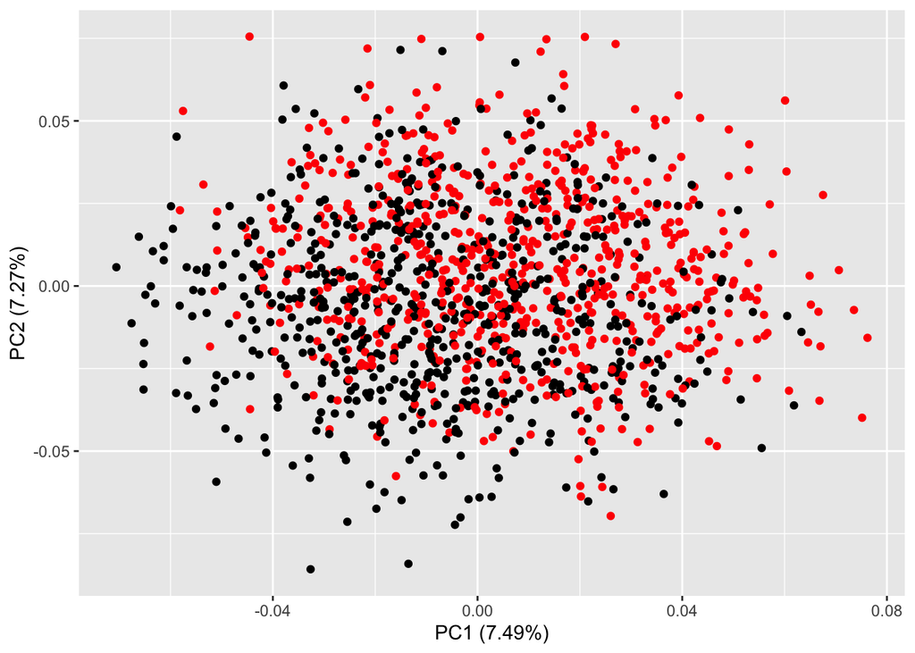

```r
# color PCA plot according to clusters from k-means analysis:
a <- autoplot(prcomp(HCV[1:16]), data = HCV[1:16], colour = kmeans_clust$cluster)
a
```